# p8105-hw1-yz4994

YiwenZhang

2025-09-19

# Problem 1

I start by loading the `moderndive` package and accessing the `early_january_weather` dataset.I have installed the package “moderndive” in the console.

Now I load required libraries

```r
library(moderndive)
library(tidyverse)
```

Now I load the dataset we need

```r
data("early_january_weather")
nrow(early_january_weather)
```

```
## [1] 358
```

```r
ncol(early_january_weather)
```

```
## [1] 15
```

```r
mean(early_january_weather$temp, na.rm = TRUE)
```

```
## [1] 39.58212
```

```r
glimpse(early_january_weather)
```

```
## Rows: 358
## Columns: 15
## $ origin     <chr> "EWR", "EWR", "EWR", "EWR", "EWR", "EWR", "EWR", "EWR", "EW…
## $ year       <int> 2013, 2013, 2013, 2013, 2013, 2013, 2013, 2013, 2013, 2013,…
## $ month      <int> 1, 1, 1, 1, 1, 1, 1, 1, 1, 1, 1, 1, 1, 1, 1, 1, 1, 1, 1, 1,…
## $ day        <int> 1, 1, 1, 1, 1, 1, 1, 1, 1, 1, 1, 1, 1, 1, 1, 1, 1, 1, 1, 1,…
## $ hour       <int> 1, 2, 3, 4, 5, 6, 7, 8, 9, 10, 11, 13, 14, 15, 16, 17, 18, …
## $ temp       <dbl> 39.02, 39.02, 39.02, 39.92, 39.02, 37.94, 39.02, 39.92, 39.…
## $ dewp       <dbl> 26.06, 26.96, 28.04, 28.04, 28.04, 28.04, 28.04, 28.04, 28.…
## $ humid      <dbl> 59.37, 61.63, 64.43, 62.21, 64.43, 67.21, 64.43, 62.21, 62.…
## $ wind_dir   <dbl> 270, 250, 240, 250, 260, 240, 240, 250, 260, 260, 260, 330,…
## $ wind_speed <dbl> 10.35702, 8.05546, 11.50780, 12.65858, 12.65858, 11.50780, …
## $ wind_gust  <dbl> NA, NA, NA, NA, NA, NA, NA, NA, NA, NA, NA, NA, NA, NA, 20.…
## $ precip     <dbl> 0, 0, 0, 0, 0, 0, 0, 0, 0, 0, 0, 0, 0, 0, 0, 0, 0, 0, 0, 0,…
## $ pressure   <dbl> 1012.0, 1012.3, 1012.5, 1012.2, 1011.9, 1012.4, 1012.2, 101…
## $ visib      <dbl> 10, 10, 10, 10, 10, 10, 10, 10, 10, 10, 10, 10, 10, 10, 10,…
## $ time_hour  <dttm> 2013-01-01 01:00:00, 2013-01-01 02:00:00, 2013-01-01 03:00…
```

According to the help file of the dataset, I get the following information:

1.Description:Hourly meteorological data for LGA, JFK and EWR for the month of January 2013.The dataset is a data frame of **358** rows representing hourly measurements and **15** variables (**358** rows and **15** columns).

2.The mean temperature is **39.5821229** F.

3.The variables in this dataset, including names / values of important variables:

The variables are: origin, year, month, day, hour, temp, dewp, humid, wind_dir, wind_speed, wind_gust, precip, pressure, visib, time_hour The dataset `early_january_weather` from the `moderndive` package has character variable **origin**, integer variables **year, month, day, hour**, double class variables **temp, dewp, humid, wind_dir, wind_speed, wind_gust, precip, precip, visib**, and date and time variable **time_hour**.

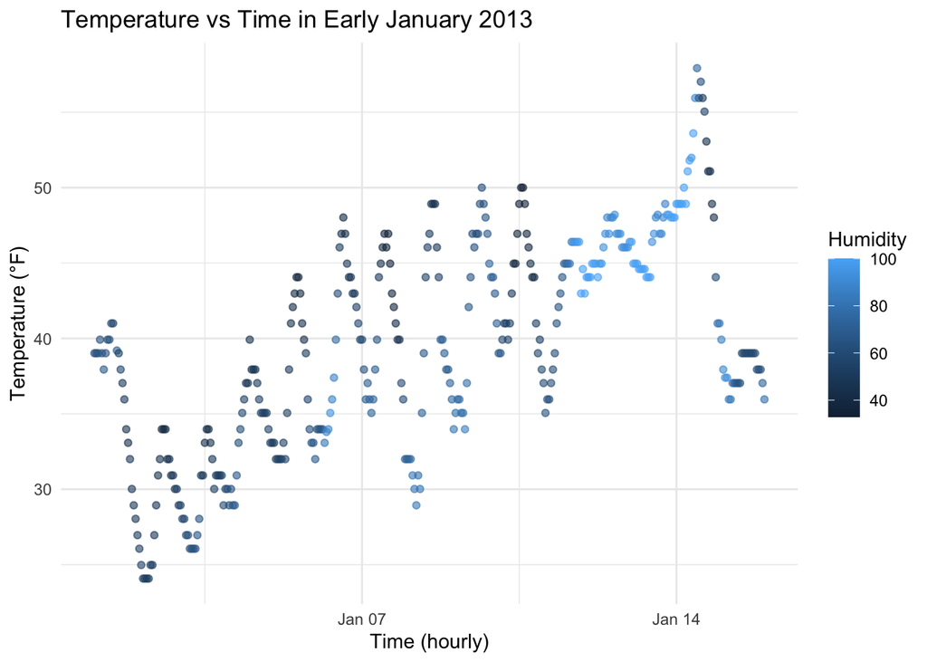

```r
ggplot(early_january_weather, aes(x = time_hour, y = temp, color = humid)) +
  geom_point(alpha = 0.6) +
  labs(
    title = "Temperature vs Time in Early January 2013",
    x = "Time (hourly)",
    y = "Temperature (°F)",
    color = "Humidity"
  ) +
  theme_minimal()
```

## Patterns

### 1.Daily fluctuations

Temperature follows a repeating cycle: it tends to dip during the early hours and rise during the daytime.

## Export the plot

```r
ggsave("scatter_temp_time.png", width = 7, height = 4)
```

# Problem 2

This problem emphasizes variable types and coercion in R.

## 1.Create the data frame

```r
set.seed(123)   # for reproducibility

df2 <- tibble(
  sample_norm = rnorm(10),                       # numeric
  logical_vec = rnorm(10) > 0,                   # logical
  char_vec = sample(letters, 10, replace = TRUE),# character
  factor_vec = factor(sample(c("low", "med", "high"), 10, replace = TRUE))
)

df2
```

```
## # A tibble: 10 × 4
##    sample_norm logical_vec char_vec factor_vec
##          <dbl> <lgl>       <chr>    <fct>
##  1     -0.560  TRUE        o        low
##  2     -0.230  TRUE        j        high
##  3      1.56   TRUE        m        med
##  4      0.0705 TRUE        g        low
##  5      0.129  FALSE       i        med
##  6      1.72   TRUE        i        low
##  7      0.461  TRUE        j        low
##  8     -1.27   FALSE       w        high
##  9     -0.687  TRUE        u        low
## 10     -0.446  FALSE       g        med
```

## 2. Take the mean of each variable

```r
mean(pull(df2,sample_norm))   # works: numeric
```

```
## [1] 0.07462564
```

```r
mean(pull(df2,logical_vec))  # works: TRUE = 1, FALSE = 0
```

```
## [1] 0.7
```

```r
mean(pull(df2,char_vec))      # fails: characters cannot be averaged
```

```
## [1] NA
```

```r
mean(pull(df2,factor_vec))    # fails: factors not numeric by default
```

```
## [1] NA
```

## 3. Explanation

```markdown
- **Numeric variable**: Taking the mean works as expected.
- **Logical variable**: Taking the mean works; R treats `TRUE = 1` and `FALSE = 0`. The mean is the proportion of TRUE values.
- **Character variable**: Taking the mean fails because characters cannot be coerced to numbers automatically.
- **Factor variable**: Taking the mean fails because factors are categorical labels, not numeric.
```

## 4. Using `as.numeric`

```r
as.numeric(pull(df2,logical_vec))   # converts TRUE/FALSE → 1/0
as.numeric(pull(df2,char_vec))      # returns NA with warning (cannot convert letters to numbers)
as.numeric(pull(df2,factor_vec))    # converts factor levels → underlying integer codes (1, 2, 3)
```

[output not shown]

## Explanation

```markdown
- Converting **logical** to numeric turns TRUE/FALSE into 1/0, which explains why taking the mean of a logical vector gives the proportion of TRUEs.
- Converting **character** to numeric produces NAs (with a warning), since characters like "a", "b", "c" have no numeric representation.
- Converting **factor** to numeric produces the underlying integer codes of the factor levels, not the labels. This explains why I can’t take a mean of factors directly — the numbers would represent codes, not meaningful values.
```